# DAPR1 Assessed report

Academic year 2025-26

# A. Instructions

The assessed report requires you to address some questions of interest (Q1-Q4) detailed in Section C, considering the background and study aims presented in Section B. Each question of interest relates to a different week of teaching in block 4.

## Submission instructions

Your group is required to **submit a PDF report of maximum 6 pages by 12 noon on Friday the 27th of March 2026**. The task(s) for this assignment are designed to take 28 days. All students have been given up to 35 days. This applies any extra time requirements and ensures that there is sufficient time for all students to complete the task (extra time for groupwork has been [mainstreamed](https://disability-learning-support-service.ed.ac.uk/staff/adjustments/mainstreaming-adjustments)). No additional extra time adjustments will be considered.

Every member of the group must have joined the group on LEARN (see group name on the desk in the lab). Otherwise, the grade will be 0 for those not registered.

The file name should include the exam numbers of all group members, e.g. “*B000001, B000002, B000003, B000004.pdf*”. You can find your exam number on your student card, and it starts with the letter B. You must also use the same title for your Turnitin Submission Title, see below:

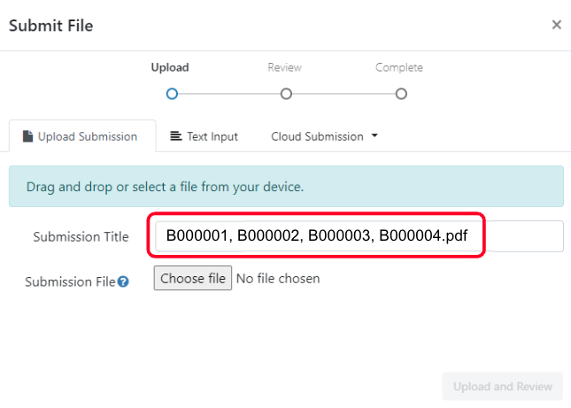

Turnitin submission title example

In the author part of the PDF file, specify the exam number of everyone within the group (for example: B000001, B000002, B000003, …). The exam number starts with a letter B and can be found on your student card. **If your exam number is not within the list of authors, you will receive a 0 grade for the report.**

Only one person is required to submit on behalf of the entire group. To submit, go to the course LEARN page, click “Assessment”, and then click “Submit Assessed report (PDF file only)”. Once you’ve submitted on behalf of your group, let the other group members know by writing a message on the LEARN Group Discussion Space.

## Report requirements

The submitted report should have the following sections:

- *Introduction*: contains a brief introduction to the data, questions being investigated, variables under consideration, their type and/or ranges (where applicable).
- *Analysis*: contains clear descriptions and details of the analyses performed, including assumptions and justifications, as well as your results write-ups.  
  This should include text, tables, and/or figures, and you should ensure you interpret the key statistical results and/or figures presented.
- *Discussion*: provides a short summary which answers the questions being investigated with a few take-home messages. It should also include ideas for future work and/or address limitations of the current work.
- *Appendix A (optional)*: for additional figures and tables. This does not count towards the page limit and is optional: if all your figures/tables fit in the main part of the report, you can skip this. Any figure or table included here must be referenced in the main part of the report and also have a caption.
- *Appendix B (compulsory)*: showing all the R code used. This does not count towards the page limit. Unlike Appendix A, Appendix B is compulsory and must be included in the report.

With the exclusion of Appendix B, the report should not have any visible R code or R printout of output. In other words, it should only feature text, plots, and tables and be properly formatted.

The default tables produced by R are not appropriate for a report. You need to use a function such as `kbl()` or `kable()` from the kableExtra package to produce report-quality tables.

## Peer assessment of contribution

Ensure you rate the contribution of everyone in your group on LEARN using the WebPA tool. This will open on the report due date and close two weeks afterwards. Announcements will be sent on both occasions.

- You must rate the contribution of each person in your group on a scale from 0 to 5.
- If you do not contribute any peer-adjustment marks, the other group members’ marks will have more influence.
- You can find a visual illustration of how peer assessment of contribution works at [this website](https://uoe-psy.shinyapps.io/peer_adj/). Please note that this is for demonstration purpose only.

## Lab attendance

The report is based on group work during the labs. You must go to the labs to work with the members of your table group.

**If you attend none of the labs during the five weeks that will lead to the creation of the assessed report, you will receive a grade of 0.**

## Grading criteria

Your report will be indicatively assessed based on four key areas: Introduction, Analysis, Discussion, and Appendices. The Introduction (15%) should provide clear context, define variables, and outline the research questions, addressing any missing or impossible values. The Analysis (60%) will be evaluated on the correct application of exploratory data analysis, statistical methods, assumption checks, APA-compliant reporting, and interpretation of results for each of the four questions of interest. The Discussion (15%) should summarise findings, interpret their implications for the university’s questions of interest, and highlight limitations and suggestions for future work. Finally, the Appendix (10%) will be assessed on the usage and quality of additional figures/tables (if needed) and the completeness, structure, and clarity of R code provided.

The grading of each section will also consider your accuracy, clarity, and insightfulness, so ensure your report is organised, concise, and aligned with the study’s objectives.

## Policy on AI use

Academic integrity is an underlying principle of research and academic practice. All submitted work is expected to be your own. AI tools (e.g., ELM) should not be used for assessments on DAPR1. Using AI would constitute academic misconduct.

# B. Study background and aims

The University of Edinburgh’s Student Wellbeing Service wants to investigate how students’ sleep patterns relate to their academic performance and stress levels. The service is particularly interested in understanding whether different accommodation types and study habits impact sleep quality and academic outcomes.

The university recruited 120 undergraduate students from various programs to participate in a wellbeing study. Over the course of one semester, researchers tracked students’ average nightly sleep duration during weekdays and weekends, recording the total average weekly sleep. Additionally, students reported whether they were regular library users or primarily studied at home. Students also completed the Perceived Stress Scale (PSS-10), a validated stress assessment with scores theoretically ranging between 0 and 40, where higher scores indicate greater stress.

The university aims to better understand student wellbeing and its relationship to academic success. This includes comparing sleep patterns to national student averages, examining the impact of accommodation type on stress levels, exploring differences in weekday versus weekend sleep habits. Additionally, researchers are interested in whether students’ living arrangements relate to their study location preferences, as this may affect access to quiet study spaces and overall wellbeing. These insights will guide future student support services and accommodation policies.

The following link, https://uoepsy.github.io/data/dapr1_2526_ar_data.csv, gives you access to data on the following variables:

- `student_id`: unique participant identifier
- `study_location` (library/home): indicates whether the student primarily studies in the library or at home
- `accommodation` (halls/private): indicates whether the student lives in university halls or private accommodation
- `pss_score`: score on the PSS-10 Perceived Stress Scale
- `weekday_sleep`: average nightly sleep duration during weekdays (hours)
- `weekend_sleep`: average nightly sleep duration during weekends (hours)
- `total_sleep`: weighted average of weekday and weekend sleep

Your task is to analyse the data, answer the questions of interest, and interpret the results in relation to the university’s wellbeing concerns.

# C. Tasks

### Significance level

Throughout the entire report, use a 5% significance level (i.e., $\alpha = .05$) and the p-value method for hypothesis testing.

### Expectations

For each question of interest detailed below:

- Present appropriate visualisations and descriptive statistics of the relevant variables in APA format.
- Perform the appropriate statistical test and report the results in APA format, including all key information.
- Follow up a statistically significant result by:
  - commenting on effect size and determining whether the results are practically significant (i.e., important).
  - reporting a confidence interval (CI) and interpreting it in the context of the study. Please note that you are not expected to report a CI for Q4 as the R function for that test doesn’t return a CI.
- Interpret your results in the context of the study and explain their meaning and implication for the university.
- Check whether the assumptions underlying the statistical test are met and address any assumption checks in your write-ups.

### Questions of interest

- **Q1:** Is the average total weekly sleep of Edinburgh students different from the national student population? National statistics suggest that the typical UK university student sleeps on average 7.5 hours per night.
- **Q2:** Do stress levels differ between students living in different accommodation types?
- **Q3:** Do students sleep more on weekends compared to weekdays?
- **Q4:** Is there an association between being a regular library user and accommodation type?